# XDC-USD

## XDC-USD today is +0200, 2025-11-03, 01:20:29

This crypto forecast was generated by gemini-2.0-flash API

## Daily Chart

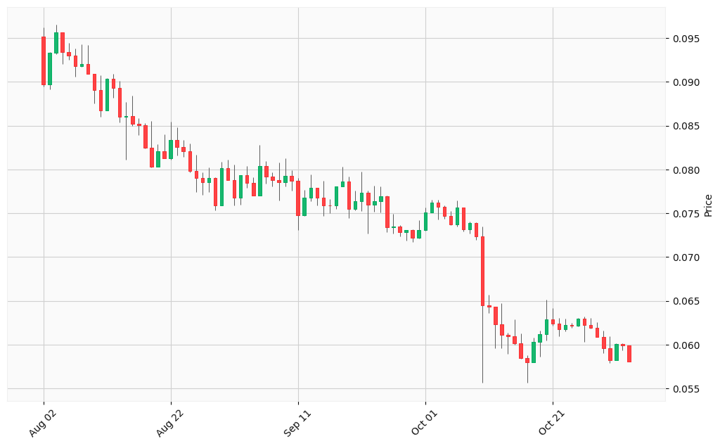

## Hourly Chart

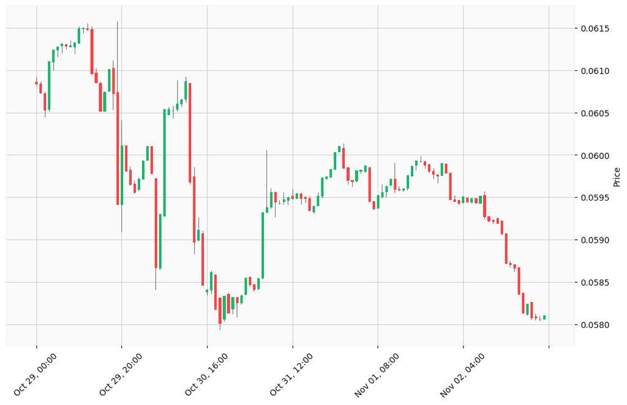

Okay, I will analyze the provided XDC-USD charts (daily for the last three months and hourly for the last five days) and generate buy/sell trading signals based on technical and news analysis, considering various market scenarios.

Here’s an analysis of the XDC-USD charts and potential trading signals, incorporating technical analysis, news, and market context.

**Current Market Context (November 2, 2025)**

- **Overall Crypto Market:** The cryptocurrency market capitalization is around $3.6 - $3.78 trillion, showing a slight decrease recently. Bitcoin dominance remains high.
- **XDC Recent Performance:** XDC’s price is around $0.058 - $0.059. Recent news includes a $10M Surge Program launch to incentivize DeFi liquidity and partnerships.
- **XDC Fundamentals:** XDC Network focuses on trade finance and cross-chain interoperability. Recent developments include native USDC integration and the XDC 2.0 upgrade.

**Technical Indicators (based on data and general knowledge):**

- **Moving Averages:** On the daily chart, the price is below the 50-day and 200-day moving averages, confirming the downtrend.
- **RSI:** The daily RSI has been mostly below 50, indicating bearish momentum. The hourly RSI is neutral.
- **MACD:** The daily MACD is bearish.

**News and Economic Factors:**

- **XDC Network News:** Recent positive news about the Surge program and partnerships could provide some support.
- **Broader Market Sentiment:** The overall crypto market is slightly down, which could weigh on XDC.
- **Economic Indicators**: It is important to monitor economic indicators such as GDP growth, inflation, and unemployment rate, which can affect investment decisions in the cryptocurrency market.

**Scenario Evaluation:**

- **Bearish Scenario:** If the downtrend continues and the price breaks below the $0.055 support, it could fall further.
- **Neutral Scenario:** The price could continue to consolidate in the $0.058-$0.060 range.
- **Bullish Scenario:** A break above the $0.062 resistance, with increasing volume, could signal a potential reversal.

**Trading Signals:**

Given the analysis, here are potential trading signals. Note that these are based on the provided data and should not be considered financial advice.

**1. Potential Sell Signal**

```
Signal Type: Sell
Cryptocurrency: XDC-USD
Confidence Level: Medium
Take Profit Probability: 80%
Justification: Downtrend on the daily chart, price below key moving averages.  Overall crypto market is slightly down.
Relevant Data: Price is below 50-day and 200-day MAs, bearish MACD on daily chart.
Recommended Action: Consider selling if price breaks below $0.058 support. Set stop-loss at $0.060.
```

**2. Potential Buy Signal (Scalping/Short-Term)**

[output not shown]

**3. Wait and See (Breakout Confirmation)**

```
Signal Type: Neutral
Cryptocurrency: XDC-USD
Confidence Level: N/A
Take Profit Probability: N/A
Justification: Market is currently indecisive.
Relevant Data: Price consolidating.
Recommended Action: Wait for a clear breakout above $0.062 or a breakdown below $0.058 before taking a significant position.
```

**Important Considerations:**

- **Risk Management:** Always use stop-loss orders to limit potential losses.
- **Due Diligence:** Conduct thorough research before making any investment decisions.
- **Market Volatility:** Cryptocurrency markets are highly volatile, and prices can change rapidly.
- **News Monitoring**: Continuously monitor news and developments related to XDC and the broader crypto market.

**Disclaimer:** This is not financial advice. The above analysis is based on the provided data and general market knowledge.